# 101_aircraft

## Observaciones de aviones en los prepbufrs

Los prepbufrs contienen 3 tipos de observaciones provenientes de aviones:

- 130/230: AIREP
- 131/231: AMDAR
- 133/233: MDCRS ACARS

Por ahora según la configuración de la **errtable** algunas observaciones de humedad no se asimilan (también está así en el archivo **convinfo**).

| tipo | temp | q | uv |
| --- | --- | --- | --- |
| 130 | 2.5 | NA | - |
| 131 | 1.47 | NA | - |
| 133 | 1.47 | 1.94 | - |
| 230 | - | - | 3.6 |
| 231 | - | - | 3.0 |
| 233 | - | - | 2.5 |

También parece haber otros [tipos de reportes](https://www.emc.ncep.noaa.gov/mmb/data_processing/prepbufr.doc/table_21.htm) que incorporan las observaciones de masa y viento en un solo perfil, pero hasta ahora no me encontré con ninguno de esos en los prepbufr.

### Quality markers

Al parecer hay un tipo de avión que siempre es rechazado en el análisis. Esto podría deberse a que tiene un QM específico en el prepbufr que previene la asimilación.

[Tabla de QM general](https://www.emc.ncep.noaa.gov/mmb/data_processing/prepbufr.doc/table_7.htm)

Ubicación de las observaciones de aviones para el 22/11/2018 a las 00Z (más, menos 1 hora). Se superponen las observaciones de q y t con las de viento.

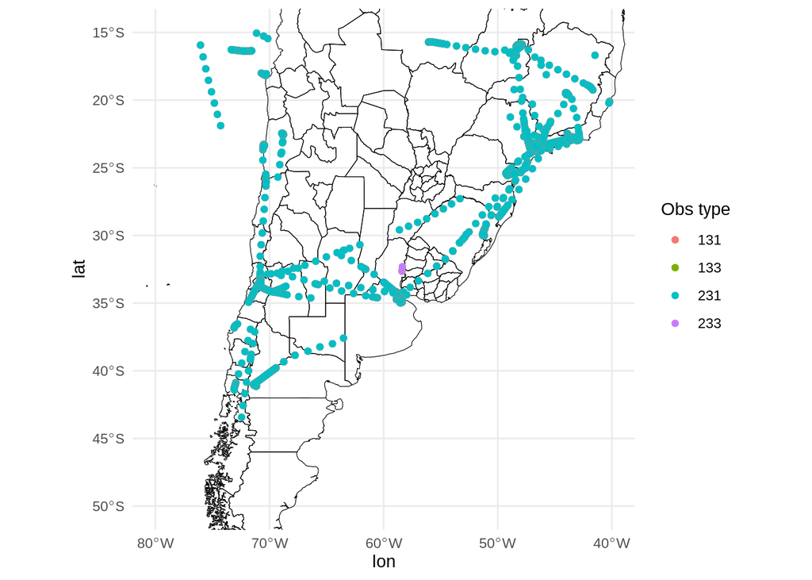

El quality marker para este tipo de observaciones (y al menos en este prepbufr) toma valores 1, 13 y 14. De acuerdo a la tabla 7 esto significa:

- 1: All steps: Good. Applies to pressure, height, wind, temperature, specific humidity, rainfall rate, precipitable water and cloud top pressure.
- 13:
  - All automated quality control steps: A non-wind profiler observation failed one or more checks. Applies to pressure, height, wind, temperature, specific humidity and precipitable water.
  - Step CQCPROF: A wind profiler report in Table A entry PROFLR failed one or more checks. Applies to wind.
  - Data producer: A wind profiler report in Table A entry PROFLR fails median check performed by NOAA/ERSL/GSD, but passes shear check. Applies to wind.
- 14: NCEP/SDM: An observation is assigned a purge flag. Applies to pressure, height, wind, temperature and specific humidity. (SDM = NCO Senior Duty Meteorologists).

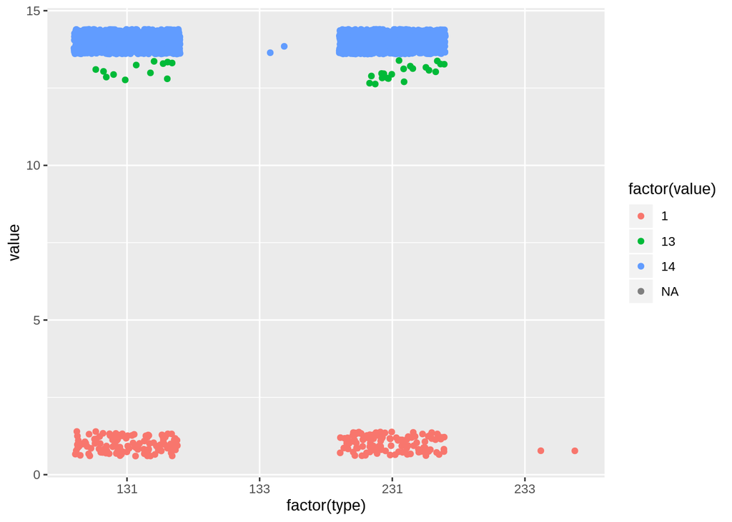

[output not shown]

Intentando encontrar que hacen las pobres observaciones para que se ganen el 14:

De este link: https://rda.ucar.edu/docs/formats/nmc/on29.txt

TABLE Q.6 P | Monitor purge (see Note 1). | 14 Note 1 - For AIREP, PIREP, and ASDAR aircraft data after 1200 UTC 5 August 1992: The character “P” in the first quality indicator position followed by a blank in the second quality indicator position indicates the entire report has been manually purged by the NMC/SDM. Character “P” in the first and second quality indicator positions indicates the entire report has been automatically purged by pgm “QCAIRCFT”.

De este otro link:

http://citeseerx.ist.psu.edu/viewdoc/download?doi=10.1.1.55.1070&rep=rep1&type=pdf

Manual (monitore) purge. Never use this data no matter what. The QAM (human quality control) has manually set this switchto force this datum to NOT be used by the analysis.